# Resolução da Atividade 3

Econometria Aplicada à Finanças  
Mestrado Profissional em Administração

Autor

Prof. Dr. Washington S. da Silva

Data de Publicação

18 de novembro de 2025

# Questão 1

## **A.**

**DicaSolução**

O modelo econométrico usado para estimar o CAPM é um modelo de regressão linear simples porque contém apenas uma variável explicativa, no caso, os retorns excedentes da carteira do mercado, ou prêmio de risco da carteira de mercado.

Em um modelo de regressão linear, o termos de erro aleatório $e_i$ cumpre o papel de capturar tudo que afeta $y_i$ e que não está incluído explicitamente no modelo:

- **Omissão de variáveis relevantes**: fatores que influenciam $y_i$ além de $x_i$;
- **Erros de medição** na variável dependente, e;
- **Choques aleatórios**.

## **B.**

**DicaSolução**

```r
# calcula retornos excedentes
dados_capm <- capm5 |>
  transmute(
    # calcula os retornos excedentes das ações e do S&P 500
    ret_ge_excedentes = ge - riskfree,
    ret_ibm_excedentes = ibm - riskfree,
    ret_ford_excedentes = ford - riskfree,
    ret_msft_excedentes = msft - riskfree,
    ret_dis_excedentes = dis - riskfree,
    ret_xom_excedentes = xom - riskfree,
    ret_mkt_excedentes = mkt - riskfree
)

# estima os modelos CAPMs via MQO
capm_ge <- lm(ret_ge_excedentes ~ ret_mkt_excedentes, data = dados_capm)
capm_ibm <- lm(ret_ibm_excedentes ~ ret_mkt_excedentes, data = dados_capm)
capm_ford <- lm(ret_ford_excedentes ~ ret_mkt_excedentes, data = dados_capm)
capm_msft <- lm(ret_msft_excedentes ~ ret_mkt_excedentes, data = dados_capm)
capm_dis <- lm(ret_dis_excedentes ~ ret_mkt_excedentes, data = dados_capm)
capm_xom <- lm(ret_xom_excedentes ~ ret_mkt_excedentes, data = dados_capm)

# exibe os resultados
broom::tidy(capm_ge)
```

```
# A tibble: 2 × 5
  term                estimate std.error statistic  p.value
  <chr>                  <dbl>     <dbl>     <dbl>    <dbl>
1 (Intercept)        -0.000959   0.00442    -0.217 8.29e- 1
2 ret_mkt_excedentes  1.15       0.0895     12.8   4.47e-27
```

```r
broom::tidy(capm_ibm)
```

```
# A tibble: 2 × 5
  term               estimate std.error statistic  p.value
  <chr>                 <dbl>     <dbl>     <dbl>    <dbl>
1 (Intercept)         0.00605   0.00483      1.25 2.12e- 1
2 ret_mkt_excedentes  0.977     0.0978       9.98 6.37e-19
```

```r
broom::tidy(capm_ford)
```

```
# A tibble: 2 × 5
  term               estimate std.error statistic  p.value
  <chr>                 <dbl>     <dbl>     <dbl>    <dbl>
1 (Intercept)         0.00378    0.0102     0.370 7.12e- 1
2 ret_mkt_excedentes  1.66       0.207      8.03  1.27e-13
```

```r
broom::tidy(capm_msft)
```

```
# A tibble: 2 × 5
  term               estimate std.error statistic  p.value
  <chr>                 <dbl>     <dbl>     <dbl>    <dbl>
1 (Intercept)         0.00325   0.00604     0.538 5.91e- 1
2 ret_mkt_excedentes  1.20      0.122       9.84  1.63e-18
```

```r
broom::tidy(capm_dis)
```

```
# A tibble: 2 × 5
  term               estimate std.error statistic  p.value
  <chr>                 <dbl>     <dbl>     <dbl>    <dbl>
1 (Intercept)         0.00105   0.00468     0.224 8.23e- 1
2 ret_mkt_excedentes  1.01      0.0946     10.7   6.50e-21
```

```r
broom::tidy(capm_xom)
```

```
# A tibble: 2 × 5
  term               estimate std.error statistic       p.value
  <chr>                 <dbl>     <dbl>     <dbl>         <dbl>
1 (Intercept)         0.00528   0.00354      1.49 0.137
2 ret_mkt_excedentes  0.457     0.0716       6.38 0.00000000148
```

#### Interpretação dos betas

- General Electric — $\beta \approx 1,15$: A ação apresenta risco sistemático maior que o do mercado. Em média, seus retornos variam mais intensamente que o índice de mercado.
- IBM — $\beta \approx 0,98$: O risco sistemático é praticamente igual ao risco do mercado. A ação tende a acompanhar as oscilações do mercado com intensidade semelhante.
- Ford — $\beta \approx 1,66$: É a ação mais sensível às oscilações do mercado entre as analisadas. Possui risco sistemático elevado.
- Microsoft — $\beta \approx 1,20$: Apresenta risco sistemático acima do mercado, com variações mais amplas que as do índice.
- Disney — $\beta \approx 1,01$: O comportamento é muito próximo ao do mercado, com risco sistemático levemente superior a 1.
- Exxon-Mobil — $\beta \approx 0,46$: A ação possui risco sistemático relativamente baixo. Suas oscilações tendem a ser menos intensas que as do mercado.
- Ação mais **agressiva**: Ford, por apresentar o maior beta estimado.
- Ação mais **defensiva**: Exxon-Mobil, por apresentar o menor beta estimado.

#### Por que não é suficiente analisar apenas as estimativas pontuais

As estimativas pontuais não capturam a incerteza associada ao estimarmos beta com uma amostra. É necessário considerar erros-padrão e intervalos de confiança para avaliar a precisão da estimativa e verificar se diferenças entre betas são estatisticamente relevantes. Sem essa informação, não sabemos se diferenças entre betas são reais ou apenas resultado da variabilidade amostral.

**DicaSolução Alternativa**

O código abaixo mostra uma solução mais eficiente caso fosse necessário estimar o capm para diversas empresas, é apenas uma ilustração da importância de se tornar um usuário avançado de linguagens de programação, pois isso o torna muito mais produtivo e eficiente. Os comentários buscam explicar o que foi feito.

Além disso, chamo atenção para o pacote fixest que, além das vantagens mencionadas em aula, possui recursos como a possibilidade de estimar diversos modelos de regressão simultaneamente e a função `etable` para criar tabelas limpas e sucintas para exibir os resultados.

```r
# Cria uma nova data frame com os retornos excedentes
# A função mutate() cria novas variáveis
# across() aplica a operação (retorno - riskfree) para várias colunas ao mesmo tempo
# .names = "retex_{.col}" gera nomes como retex_ge, retex_ibm, etc.
dados_ex <- capm5 %>%
  dplyr::mutate(
    dplyr::across(
      c(ge, ibm, ford, msft, dis, xom, mkt),     # variáveis às quais aplicar a operação
      ~ .x - riskfree,                           # cálculo dos retornos excedentes
      .names = "retex_{.col}"                    # prefixo das variáveis criadas
    )
  )

# Estima simultaneamente os modelos CAPM via MQO para todas as ações
# A sintaxe c(y1, y2, ...) ~ x permite estimar várias regressões em
# uma única chamada
modelo_fixest <- feols(
  c(retex_ge, retex_ibm, retex_ford, retex_msft, retex_dis, retex_xom) ~ retex_mkt,
  data = dados_ex
)

# etable é uma função do pacote fixest
# sendo uma das funções para apresentação dos resultados
fixest::etable(modelo_fixest, digits = 3, vcov = "HC1")
```

```
                modelo_fixest.1  modelo_fixest.2 modelo_fixest.3
Dependent Var.:        retex_ge        retex_ibm      retex_ford

Constant        -0.0010 (0.004)    0.006 (0.005)   0.004 (0.010)
retex_mkt       1.15*** (0.109) 0.977*** (0.104) 1.66*** (0.348)
_______________ _______________ ________________ _______________
S.E. type       Heteroske.-rob. Heterosked.-rob. Heteroske.-rob.
Observations                180              180             180
R2                      0.48009          0.35901         0.26600
Adj. R2                 0.47717          0.35540         0.26187

                modelo_fixest.4 modelo_fixest.5  modelo_fixest.6
Dependent Var.:      retex_msft       retex_dis        retex_xom

Constant          0.003 (0.006)   0.001 (0.005)    0.005 (0.004)
retex_mkt       1.20*** (0.118) 1.01*** (0.104) 0.457*** (0.069)
_______________ _______________ _______________ ________________
S.E. type       Heteroske.-rob. Heteroske.-rob. Heterosked.-rob.
Observations                180             180              180
R2                      0.35227         0.39091          0.18614
Adj. R2                 0.34863         0.38749          0.18156
---
Signif. codes: 0 '***' 0.001 '**' 0.01 '*' 0.05 '.' 0.1 ' ' 1
```

## **C.**

**DicaSolução**

#### Alpha ($\alpha$) de Jensen: Revisão

O intercepto do modelo CAPM (conhecido como **$\alpha$ de Jensem**) é uma medida de **retorno anormal**, ele mede o retorno que a ação (ou uma carteira) gera em excesso do que seria esperado dada sua exposição ao prêmio de risco de mercado $\beta_j(r_m - r_f)$.

O alpha de Jensen mede o retorno excedente médio de um ativo arriscado em relação ao que seria esperado dado o seu nível de risco sistemático, representado pelo beta. Ele indica se a ação entregou mais, exatamente, ou menos retorno do que o previsto pelo CAPM após ajustar pela exposição ao mercado.

Um **alpha positivo** significa que o ativo apresentou desempenho acima do esperado para o seu risco; um **alpha igual a zero** indica desempenho **consistente com o risco assumido**; e um **alpha negativo** aponta para desempenho **inferior ao esperado**. A interpretação é válida apenas quando o alpha é estatisticamente significativo; caso contrário, a diferença em relação ao retorno previsto pode ser explicada por variações aleatórias.

Além disso, o alpha de Jensen é amplamente utilizado para avaliar e comparar carteiras, fundos e seus gestores, pois permite verificar se o retorno alcançado decorre apenas da exposição ao risco de mercado (beta) ou se existe um componente de desempenho adicional atribuível à gestão. Por isso, ele é uma métrica central na análise de performance ajustada ao risco em gestão de portfólios.

#### Ford

No caso da Ford:

```r
# capm estimado para a Ford
broom::tidy(capm_ford, conf.int = TRUE)
```

```
# A tibble: 2 × 7
  term               estimate std.error statistic  p.value conf.low conf.high
  <chr>                 <dbl>     <dbl>     <dbl>    <dbl>    <dbl>     <dbl>
1 (Intercept)         0.00378    0.0102     0.370 7.12e- 1  -0.0164    0.0240
2 ret_mkt_excedentes  1.66       0.207      8.03  1.27e-13   1.25      2.07
```

#### General Electric

No caso da General Eletric:

```r
# capm estimado para a General Electric
broom::tidy(capm_ge, conf.int = TRUE)
```

```
# A tibble: 2 × 7
  term                estimate std.error statistic  p.value conf.low conf.high
  <chr>                  <dbl>     <dbl>     <dbl>    <dbl>    <dbl>     <dbl>
1 (Intercept)        -0.000959   0.00442    -0.217 8.29e- 1 -0.00969   0.00777
2 ret_mkt_excedentes  1.15       0.0895     12.8   4.47e-27  0.971     1.32
```

#### Exxon-Mobil

Para a Exxon-Mobil,

```r
# capm estimado para a Exxon-Mobil
broom::tidy(capm_xom, conf.int = TRUE)
```

```
# A tibble: 2 × 7
  term               estimate std.error statistic     p.value conf.low conf.high
  <chr>                 <dbl>     <dbl>     <dbl>       <dbl>    <dbl>     <dbl>
1 (Intercept)         0.00528   0.00354      1.49     1.37e-1 -0.00169    0.0123
2 ret_mkt_excedentes  0.457     0.0716       6.38     1.48e-9  0.315      0.598
```

a estimativa pontual do alpha foi 0.00528, ou 0.528%, mas a estimativa não é estatisticamente diferente de zero, pois a estimativa por intervalo de confiança (95%) contém zero. Além disso, o valor-p do teste t foi 0.137, portanto, novamente, pode-se concluir que a estimativa do intercepto do modelo CAPM estimado para as ações da Exxon-Mobil corresponde à previsão do teórica do CAPM ($\alpha_{xom} = 0$).

## **E.**

**DicaSolução**

#### Estimativas por intervalo de confiança dos betas

A estimativa por intervalo com 95% de confiança para o beta da Exxon-Mobil é:

```r
# capm estimado para a Exxon-Mobil
broom::tidy(capm_xom, conf.int = TRUE)
```

```
# A tibble: 2 × 7
  term               estimate std.error statistic     p.value conf.low conf.high
  <chr>                 <dbl>     <dbl>     <dbl>       <dbl>    <dbl>     <dbl>
1 (Intercept)         0.00528   0.00354      1.49     1.37e-1 -0.00169    0.0123
2 ret_mkt_excedentes  0.457     0.0716       6.38     1.48e-9  0.315      0.598
```

Ou seja, $\beta_{xom}^{95\%} = [0.315, 0.598]$

E a estimativa por intervalo com 95% de confiança para o beta da Microsoft é:

```r
# capm estimado para a Microsoft
broom::tidy(capm_msft, conf.int = TRUE)
```

```
# A tibble: 2 × 7
  term               estimate std.error statistic  p.value conf.low conf.high
  <chr>                 <dbl>     <dbl>     <dbl>    <dbl>    <dbl>     <dbl>
1 (Intercept)         0.00325   0.00604     0.538 5.91e- 1 -0.00866    0.0152
2 ret_mkt_excedentes  1.20      0.122       9.84  1.63e-18  0.961      1.44
```

Ou seja, $\beta_{msft}^{95\%} = [0.961, 1.44]$

#### Explicação a um investidor

Com estas estimativas, eu diria algo mais ou menos assim a um investidor:

“Quando falamos em beta, estamos medindo o quanto o retorno de uma ação tende a reagir aos movimentos do mercado como um todo. Um beta igual a 1 significa que, em média, a ação se move na mesma intensidade que o mercado; abaixo de 1, tende a oscilar menos; acima de 1, tende a oscilar mais. Os intervalos de confiança de 95% não são apenas dois números, mas uma faixa de valores razoavelmente plausíveis para esse beta, baseada nos dados históricos.

No caso da Exxon-Mobil, o intervalo de 95% para o beta vai de 0,315 a 0,598. Isso quer dizer que, com base nos dados que temos, é muito provável que a sensibilidade da ação da Exxon aos movimentos do mercado seja claramente menor do que a do próprio mercado. Em outras palavras, quando o índice de mercado sobe ou cai, a ação da Exxon tende, em média, a variar bem menos do que o índice. Para você, como investidor, isso significa que a Exxon-Mobil é uma ação de risco sistemático relativamente baixo: ela ainda acompanha a direção geral do mercado, mas com amplitude reduzida. Em uma carteira, ela tende a contribuir para suavizar as oscilações causadas por choques no mercado, o que é interessante para perfis mais conservadores dentro da renda variável ou para quem busca reduzir a volatilidade total da carteira sem sair totalmente de ações.

Já a Microsoft apresenta um intervalo de 95% para o beta entre 0,961 e 1,44. Esse intervalo inclui 1, o que indica que os dados são compatíveis com um beta muito próximo ao do mercado, mas também admitem a possibilidade de a ação ser significativamente mais sensível do que o mercado. Em termos práticos, isso quer dizer que a Microsoft, no mínimo, se comporta de forma semelhante ao mercado, e possivelmente oscila mais. Para você, isso implica que, ao investir em Microsoft, está assumindo um risco sistemático igual ou um pouco superior ao risco do próprio mercado acionário. É o tipo de ação mais adequada a um perfil moderado ou arrojado, que aceita variações mais pronunciadas no valor da carteira em troca de maior potencial de retorno.

Em resumo, a ação da Exxon-Mobil tende a reagir menos aos movimentos do mercado, enquanto a ação da Microsoft tende a reagir na mesma intensidade ou de forma mais acentuada. Se o seu objetivo é montar uma carteira que sofra menos com oscilações amplas do mercado, a Exxon-Mobil é uma candidata natural. Se, por outro lado, você busca uma carteira com maior exposição ao risco de mercado, aceitando mais volatilidade em troca de maior potencial de retorno, a Microsoft cumpre esse papel. Na prática, a decisão não costuma ser escolher apenas uma delas, mas sim definir como combiná-las na carteira para que o risco total fique alinhado aos seus objetivos e à sua tolerância ao risco.”

## **F.**

**Dicasolução**

#### Ford

Podemos testar:

usando a função `linearHypothesis` do pacote car:

```r
# teste de beta = 0 vs. beta != 0 para a Ford
car::linearHypothesis(capm_ford, c("ret_mkt_excedentes = 0"))
```

```
Linear hypothesis test:
ret_mkt_excedentes = 0

Model 1: restricted model
Model 2: ret_ford_excedentes ~ ret_mkt_excedentes

  Res.Df  RSS Df Sum of Sq    F           Pr(>F)
1    179 4.55
2    178 3.34  1      1.21 64.5 0.00000000000013 ***
---
Signif. codes:  0 '***' 0.001 '**' 0.01 '*' 0.05 '.' 0.1 ' ' 1
```

Como sabemos, um procedimento de inferência mais informativo é obter uma estimativa por intervalo de confiança para o beta da Ford:

```r
# capm estimado para a Ford
broom::tidy(capm_ford, conf.int = TRUE)
```

```
# A tibble: 2 × 7
  term               estimate std.error statistic  p.value conf.low conf.high
  <chr>                 <dbl>     <dbl>     <dbl>    <dbl>    <dbl>     <dbl>
1 (Intercept)         0.00378    0.0102     0.370 7.12e- 1  -0.0164    0.0240
2 ret_mkt_excedentes  1.66       0.207      8.03  1.27e-13   1.25      2.07
```

Assim, com base na amostra disponível, um intervalo de confiança de 95%  
para o beta da Ford é $[1.25, 2.07]$. Assim, a sensibilidade da ação da Ford aos movimentos ou choques no mercado acionário é claramente maior que a do mercado.

#### Interpretação de $\beta = 1$

No contexto do CAPM, um beta igual a 1 indica que a ação possui risco sistemático equivalente ao da carteira de mercado. Isso significa que, em média, seus retornos tendem a se mover na mesma direção e com a mesma intensidade que as oscilações do mercado agregado. Quando o prêmio de risco do mercado varia, o prêmio de risco esperado dessa ação varia na mesma proporção.

Do ponto de vista do investidor, uma ação com beta igual a 1 não altera a sensibilidade da carteira ao risco de mercado: ela acompanha o comportamento do índice de referência. Pelo CAPM, o retorno esperado dessa ação deve ser igual ao retorno esperado do mercado, descontado o risco livre, pois ela assume exatamente o mesmo nível de risco sistemático.

#### General Electric

```r
# teste de beta = 1 vs. beta != 1 para a GE
car::linearHypothesis(capm_ge, c("ret_mkt_excedentes = 1"))
```

```
Linear hypothesis test:
ret_mkt_excedentes = 1

Model 1: restricted model
Model 2: ret_ge_excedentes ~ ret_mkt_excedentes

  Res.Df   RSS Df Sum of Sq    F Pr(>F)
1    179 0.634
2    178 0.625  1   0.00958 2.73    0.1
```

O teste F rejeita não fornece evidências para rejeitar a hipótese nula de que o beta da General Electric é igual a 1, viso que o valor-p $= 0.1$.

#### Exxon-Mobil

```r
# teste de beta = 1 vs. beta != 1 para a Exxon-Mobil
car::linearHypothesis(capm_xom, c("ret_mkt_excedentes = 1"))
```

```
Linear hypothesis test:
ret_mkt_excedentes = 1

Model 1: restricted model
Model 2: ret_xom_excedentes ~ ret_mkt_excedentes

  Res.Df   RSS Df Sum of Sq    F          Pr(>F)
1    179 0.528
2    178 0.399  1     0.129 57.7 0.0000000000017 ***
---
Signif. codes:  0 '***' 0.001 '**' 0.01 '*' 0.05 '.' 0.1 ' ' 1
```

O teste F fornece evidências para rejeitar a hipótese nula de que o beta da Exxon-Mobil é igual a 1, visto que o valor-p $<< 1$.

## **G.**

**Dicasolução**

#### Exxon-Mobil

Como sabemos, uma forma de obter a estimativa por intervalo de confiança (95%) para o beta da Exxon-Mobil é:

```r
# capm estimado para a Exxon-Mobil
broom::tidy(capm_xom, conf.int = TRUE)
```

```
# A tibble: 2 × 7
  term               estimate std.error statistic     p.value conf.low conf.high
  <chr>                 <dbl>     <dbl>     <dbl>       <dbl>    <dbl>     <dbl>
1 (Intercept)         0.00528   0.00354      1.49     1.37e-1 -0.00169    0.0123
2 ret_mkt_excedentes  0.457     0.0716       6.38     1.48e-9  0.315      0.598
```

e que $\beta_{xom}^{95\%} = [0.315, 0.598]$. Assim, posso repetir o que escrevi anteriormente sobre a interpretação desta estimativa:

“No caso da Exxon-Mobil, o intervalo de 95% para o beta vai de 0,315 a 0,598, portanto, não inclui 1. Isso quer dizer que, com base nos dados que temos, é muito provável que a sensibilidade da ação da Exxon aos movimentos do mercado seja claramente menor do que a do próprio mercado. Em outras palavras, quando o índice de mercado sobe ou cai, a ação da Exxon tende, em média, a variar bem menos do que o índice. Para você, como investidor, isso significa que a Exxon-Mobil é uma ação de risco sistemático relativamente baixo: ela ainda acompanha a direção geral do mercado, mas com amplitude reduzida. Em uma carteira, ela tende a contribuir para suavizar as oscilações causadas por choques no mercado, o que é interessante para perfis mais conservadores dentro da renda variável ou para quem busca reduzir a volatilidade total da carteira sem sair totalmente de ações.”

#### Interpretação de $\beta < 1$

Um beta menor que 1, no contexto do CAPM, significa que a ação possui **menor risco sistemático** do que o mercado como um todo. Em termos práticos, isso quer dizer que, quando o mercado sofre oscilações, os retornos dessa ação tendem a variar na mesma direção, porém com menor amplitute. Por exemplo, se o prêmio de risco do mercado aumenta ou diminui em 1 ponto percentual, o prêmio de risco esperado da ação varia, em média, menos que 1 ponto percentual.

Do ponto de vista do investidor, uma ação com beta menor que 1 é considerada “defensiva”: ela contribui para reduzir a sensibilidade da carteira às oscilações do mercado. Pelo CAPM, como ela carrega menos risco sistemático, também deve oferecer, em equilíbrio, um **retorno esperado menor** do que o retorno esperado do mercado, dado que a remuneração exigida pelos investidores é proporcional ao beta.

## **H.**

**Dicasolução**

#### Microsoft

Novamente, podemos obter a estimativa por intervalo de confiança para o beta da Microsoft com:

```r
# capm estimado para a Microsoft
broom::tidy(capm_msft, conf.int = TRUE)
```

```
# A tibble: 2 × 7
  term               estimate std.error statistic  p.value conf.low conf.high
  <chr>                 <dbl>     <dbl>     <dbl>    <dbl>    <dbl>     <dbl>
1 (Intercept)         0.00325   0.00604     0.538 5.91e- 1 -0.00866    0.0152
2 ret_mkt_excedentes  1.20      0.122       9.84  1.63e-18  0.961      1.44
```

“Portanto, a Microsoft apresenta um intervalo de 95% para o beta entre 0,961 e 1,44. Esse intervalo inclui 1, o que indica que os dados são compatíveis com um beta muito próximo ao do mercado, mas também admitem a possibilidade desta ação ser significativamente mais sensível do que o mercado. Em termos práticos, isso quer dizer que a Microsoft, no mínimo, se comporta de forma semelhante ao mercado, e possivelmente oscila mais. Para você, isso implica que, ao investir em Microsoft, está assumindo um risco sistemático igual ou um pouco superior ao risco do próprio mercado acionário. É o tipo de ação mais adequada a um perfil moderado ou arrojado, que aceita variações mais pronunciadas no valor da carteira em troca de maior potencial de retorno.”

#### Interpretação de $\beta > 1$

No contexto do CAPM, um beta maior que 1 indica que a ação possui risco sistemático superior ao da carteira de mercado. Isso significa que, em média, seus retornos tendem a se mover na mesma direção do mercado, porém com maior intensidade. Assim, quando o prêmio de risco do mercado sofre variações, o prêmio de risco esperado dessa ação varia de forma proporcionalmente maior.

Do ponto de vista do investidor, uma ação com beta maior que 1 é considerada mais sensível às oscilações do mercado: ela amplifica tanto movimentos de alta quanto de baixa. Por assumir um nível mais elevado de risco sistemático, o CAPM prevê que seu **retorno esperado** deve ser maior que o retorno esperado do mercado, descontado o risco livre. Essa característica torna ações com beta acima de 1 mais adequadas a investidores dispostos a aceitar maior volatilidade em busca de retornos potencialmente superiores.

## **I.**

**Dicasolução**

#### Obtendo o $R^2$-ajustado

Conforme a dica:

```r
# visualiza o R^2-adj do capm estimado para a Ford
summary(capm_ford)$adj.r.squared
```

```
[1] 0.26187
```

O valor do $R^2$-ajustado de aproximadamente 0,26 indica que o modelo CAPM estimado explica cerca de 26 da variação do prêmio de risco da ação da Ford. Em outras palavras, o prêmio de risco do mercado — a única variável explicativa do modelo — consegue justificar pouco mais de um quarto da variação observada nos retornos excedentes da Ford. Isso sugere que, embora exista relação entre o prêmio de risco da Ford e o prêmio de risco do mercado, uma parcela significativa da variação dos retornos não é capturada pelo CAPM, podendo ser atribuída a fatores específicos da empresa ou a outros fatores de risco não incluídos no modelo.

#### Por que o $R^2$-ajustado é mais adequado?

O $R^2$-ajustado é mais adequado porque ele corrige uma grande limitação do $R^2$ simples. Enquanto o $R^2$ simples tende a aumentar mecanicamente pelo simples fato de adicionarmos mais variáveis, mesmo que irrelevantes, o $R^2$-ajustado penaliza a inclusão de variáveis explicaticas que não contribuam de fato para melhorar o ajuste. Por isso, ele é especialmente útil quando se comparam modelos com números diferentes de variáveis explicativas ou quando se deseja avaliar a contribuição real de uma variável adicional.

## **J.**

**Dicasolução**

#### Teste RESET

```r
# teste RESET para o CAPM da ford
lmtest::resettest(capm_ford, type = "regressor")
```

```
    RESET test

data:  capm_ford
RESET = 20.3, df1 = 2, df2 = 176, p-value = 0.000000011
```

Dado que o valor-p do teste foi $\ll 1$, O resultado do teste RESET fornece evidências de que um modelo linear como o CAPM não é adequado para modelar a relação entre os retornos excedentes da Ford e os retornos excedentes da carteira de mercado (no caso, o S&P 500), visto que os termos do prêmio de risco do mercado elevados ao quadrado e ao cubo foram signficativos, o que sugere que alguma não-linearidade não foi captada pelo modelo CAPM, que é um modelo linear.

#### Gráfico dos Resíduos versus os Valores Previstos

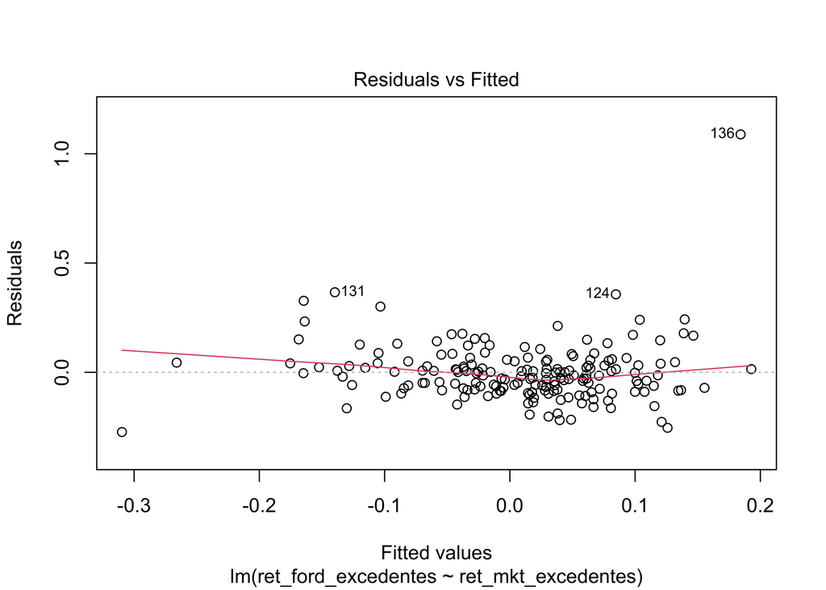

```r
# gráfico dos resíduos versus os valores ajusteados
# para o modelo capm estimado para a Ford
plot(capm_ford, which = 1)
```

Analisando o gráfico dos resíduos contra os valores previstos pelo modelo, aparentemente, a não-linearidade pode ser provocada por observações discrepantes, como as destacadas no gráfico. Essa é uma ocorrência comum quando trabalhamos com dados financeiros do mercado de capitais.

## **L**

**Dicasolução**

#### Teste de White

```r
# teste de White
whitestrap::white_test(capm_ford)
```

```
White's test results

Null hypothesis: Homoskedasticity of the residuals
Alternative hypothesis: Heteroskedasticity of the residuals
Test Statistic: 19.17
P-value: 0.000069
```

O teste de White fornece evidências para rejeitar a hipótese nula de que os resíduos do modelo CAPM estimado para a Ford possuem variância constante, visto que o valor-p $\approx = 0.00007$. O que, pela análise do gráfico dos resíduos versus os valores previstos, é esperado.

#### Implicação de Heterocedasticidade

Como vimos na disciplina, sob heterocedasticidade, os estimadores de MQO dos parâmetros de um modelo de regressão linear continuam sendo não viesados, desde que a hipótese de exogeneidade seja atendida.

Entretanto, os erros-padrão dos parâmetros são **viesados**, o que pode comprometer os procedimentos de inferência estatística, como estimativas por intervalo de confiança e testes de hipóteses envolvendo sobre os parâmetros.

#### Solução

A solução mais amplamente adotada em econometria para lidar com a heterocedasticidade é utilizar estimadores dos erros-padrão dos parâmetros robustos à heterocedasticidade.

Como vimos na disciplina, uma das formas de obter essas estimativas é utilizando a função `coeftest` do pacote lmtest combinada com a funcão `vcovHC` do pacote sandwich.

```r
# Erros-padrão robustos à heteroc. de White (HC1)
coeftest(capm_ford, vcov = vcovHC(capm_ford, type = "HC1"))
```

```
t test of coefficients:

                   Estimate Std. Error t value  Pr(>|t|)
(Intercept)         0.00378    0.00985    0.38       0.7
ret_mkt_excedentes  1.66203    0.34810    4.77 0.0000037 ***
---
Signif. codes:  0 '***' 0.001 '**' 0.01 '*' 0.05 '.' 0.1 ' ' 1
```

E podemos comparar a diferença na estimativa do erro-padrão com:

```r
# Erros-padrão de MQO
coeftest(capm_ford)
```

```
t test of coefficients:

                   Estimate Std. Error t value         Pr(>|t|)
(Intercept)         0.00378    0.01023    0.37             0.71
ret_mkt_excedentes  1.66203    0.20694    8.03 0.00000000000013 ***
---
Signif. codes:  0 '***' 0.001 '**' 0.01 '*' 0.05 '.' 0.1 ' ' 1
```

## **M.**

**Dicasolução**

#### Gráfico Quantil-Quantil Normal dos Resíduos

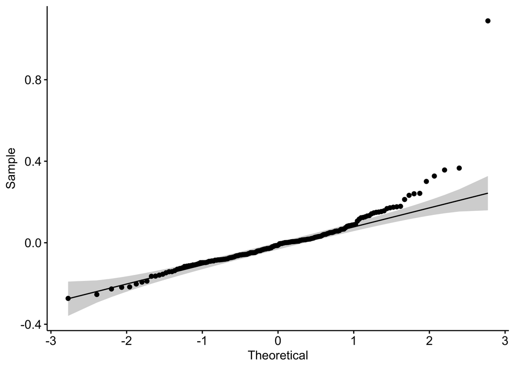

```r
# gráfico q-q normal
ggpubr::ggqqplot(capm_ford$residuals)
```

O gráfico quantil-quantil normal dos resíduos mostra que há uma assimetria positiva (à direita) substancial na distribuição dos resíduos, portanto, o gráfico sugere que a distribuição dos resíduos não é aproximadamente normal.

#### Teste Shapiro-Wilk

```r
# teste de Shapiro-Wilk
shapiro.test(capm_ford$residuals[-c(124,131,136)])
```

```
    Shapiro-Wilk normality test

data:  capm_ford$residuals[-c(124, 131, 136)]
W = 0.982, p-value = 0.025
```

Como esperado, o resultado do teste de Shapiro-Wilk fornece evidências para rejeitar a hipótese nula de que os resíduos do modelo CAPM da Ford são aproximadamente normais.

#### Normalidade dos Resíduos

Pelo teorema de Gauss-Markov, a ausência de normalidade dos resíduos não compromete as estimativas dos coeficientes do CAPM obtidas por MQO, mas afeta a inferência baseada nos testes t e F clássicos, que dependem da normalidade em amostras pequenas. Quando há assimetria (principalmente) ou caudas pesadas, os erros-padrão usuais deixam de ser confiáveis e os valores-p podem ser distorcidos. Caso a distribuição dos resíduos apresente desvios severos (como neste caso), uma alternativa é estimar o modelo com **regressão robusta baseada em estimadores-M (que vimos em aula)**, que reduz a influência de observações extremas e gera estimativas mais estáveis sob distribuições não normais. Essa abordagem reforça a confiabilidade da inferência quando os resíduos se afastam significativamente da normalidade.

# Questão 2

## **A.**

**Dicasolução**

Como vimos em aula, para o modelo de regressão linear simples, se a variável explicativa contém erro de mensuração, o limite de probabilidade do parâmetro de inclinação é:

$$\mathop{\text{plim}} \hat{\beta}_1 = \beta_1 \dfrac{\sigma_z^2}{\sigma_z^2 + \sigma_\omega^2}$$

Isso implica que o estimador de MQO é inconsistente/viesado, mesmo se $n \rightarrow \infty$. E como $\sigma_z^2 < \sigma_z^2 + \sigma_\omega^2$, erro de mensuração na variável explicativa gera um viés negativo (em direção a zero), ou seja, o estimador de MQO tende a subestimar sistematicamente o verdadeiro valor do parâmetro. Esse tipo de víes recebe o nome de viés de **atenuação**.

## **B.**

**Dicasolução**

Como já sabemos, podemos rever os resultados do modelo CAPM estimado para a Microsoft com:

```r
# capm estimado para a Microsoft
broom::tidy(capm_msft)
```

```
# A tibble: 2 × 5
  term               estimate std.error statistic  p.value
  <chr>                 <dbl>     <dbl>     <dbl>    <dbl>
1 (Intercept)         0.00325   0.00604     0.538 5.91e- 1
2 ret_mkt_excedentes  1.20      0.122       9.84  1.63e-18
```

E como também já sabemos:

- Dado que a estimativa pontual do $\beta \approx 1,20$, concluímos que esta ação apresenta risco sistemático acima do mercado, ou seja pode ser classificada como arriscada, com variações mais amplas que as do índice.

## **C.**

**Dicasolução**

```r
# Primeiro Estágio: regressão da variável endógena sobre o instrumento
# Cria o instrumento: rank da variável explicativa endógena
dados_msft <- dados_capm %>%
  # ordena a variável expl. endógena em ordem crescente
  arrange(ret_mkt_excedentes) %>%
  # cria a variável posicao em ordem crescente
  mutate(posicao = rank(ret_mkt_excedentes))

# Regressão do primeiro estágio
primeiro_estagio <- lm(ret_mkt_excedentes ~ posicao, data = dados_msft)

# exibe os resultados
broom::tidy(primeiro_estagio)
```

```
# A tibble: 2 × 5
  term         estimate std.error statistic  p.value
  <chr>           <dbl>     <dbl>     <dbl>    <dbl>
1 (Intercept) -0.0790   0.00220       -36.0 1.25e-83
2 posicao      0.000907 0.0000210      43.1 4.07e-96
```

O resultado mostra que o coeficiente estimado de `posicao` é significativo, assim, ele pode ser considerado um instrumento relevante, ele afeta a variável endógena.

## **E.**

**Dicasolução**

```r
# estima o capm para a microsoft com uma VI
reg_1est_posicao <- iv_robust(ret_msft_excedentes ~ ret_mkt_excedentes | posicao,
                diagnostics = TRUE,
                data = dados_msft)

# exibe os resultados
summary(reg_1est_posicao)
```

```
Call:
iv_robust(formula = ret_msft_excedentes ~ ret_mkt_excedentes |
    posicao, data = dados_msft, diagnostics = TRUE)

Standard error type:  HC2

Coefficients:
                   Estimate Std. Error t value               Pr(>|t|) CI Lower
(Intercept)         0.00302    0.00597   0.506 0.61372774911978822399 -0.00876
ret_mkt_excedentes  1.27832    0.13203   9.682 0.00000000000000000446  1.01778
                   CI Upper  DF
(Intercept)          0.0148 178
ret_mkt_excedentes   1.5389 178

Multiple R-squared:  0.351 ,    Adjusted R-squared:  0.347
F-statistic: 93.7 on 1 and 178 DF,  p-value: <0.0000000000000002

Diagnostics:
                 numdf dendf  value             p.value
Weak instruments     1   178 821.06 <0.0000000000000002 ***
Wu-Hausman           1   177   7.09              0.0085 **
Overidentifying      0    NA     NA                  NA
---
Signif. codes:  0 '***' 0.001 '**' 0.01 '*' 0.05 '.' 0.1 ' ' 1
```

A estimativa pontual do beta da Microsoft via MQO foi 1.20, e a estimativa usando uma variável instrumental foi $\approx 1.28$, portanto, sim, a estimativa pontual do beta via VI a previsão feita no item A, pois vê-se que a estimativa pontual do beta com MQO é menor que a estimativa pontual via variável instrumental.

## **F.**

**Dicasolução**

```r
# cria a variável pos e adiciona à df dados_msft
dados_msft <- dados_msft %>%
  mutate(
    positivo = ifelse(ret_mkt_excedentes > 0, 1, 0)
  )

# Regressão do primeiro estágio
reg_1est_2instrs <- lm(ret_mkt_excedentes ~ posicao + positivo, data = dados_msft)

# exibe os resultados
broom::tidy(reg_1est_2instrs)
```

```
# A tibble: 3 × 5
  term         estimate std.error statistic  p.value
  <chr>           <dbl>     <dbl>     <dbl>    <dbl>
1 (Intercept) -0.0804   0.00226      -35.6  1.63e-82
2 posicao      0.000982 0.0000400     24.5  7.01e-59
3 positivo    -0.00928  0.00422       -2.20 2.91e- 2
```

Vê-se que ambos os instrumentos são significativos (relevantes). Formalmente, podemos testar conjuntamente os instrumentos usando a função `linearHypothesis` do pacote car:

```r
car::linearHypothesis(reg_1est_2instrs, c("posicao = 0", "positivo = 0"))
```

```
Linear hypothesis test:
posicao = 0
positivo = 0

Model 1: restricted model
Model 2: ret_mkt_excedentes ~ posicao + positivo

  Res.Df   RSS Df Sum of Sq   F              Pr(>F)
1    179 0.438
2    177 0.037  2     0.401 951 <0.0000000000000002 ***
---
Signif. codes:  0 '***' 0.001 '**' 0.01 '*' 0.05 '.' 0.1 ' ' 1
```

O teste F rejeita fortemente (valor-p $\ll 1$) a hipótese nula de que os coeficientes de `posicao` e `positivo` sejam ambos iguais a zero, indicando que pelo menos um dos instrumentos é relevante. Portanto, os resultados fornecem evidências de que ambos os instrumentos são adequadamente relevantes.

## **G.**

**Dicasolução**

```r
# estima o capm para a microsoft com duas VIs
reg_iv <- iv_robust(ret_msft_excedentes ~ ret_mkt_excedentes | posicao + positivo,
                diagnostics = TRUE,
                data = dados_msft)

# exibe os resultados
summary(reg_iv)
```

```
Call:
iv_robust(formula = ret_msft_excedentes ~ ret_mkt_excedentes |
    posicao + positivo, data = dados_msft, diagnostics = TRUE)

Standard error type:  HC2

Coefficients:
                   Estimate Std. Error t value               Pr(>|t|) CI Lower
(Intercept)           0.003    0.00597   0.503 0.61555918478022997320 -0.00878
ret_mkt_excedentes    1.283    0.13224   9.703 0.00000000000000000391  1.02216
                   CI Upper  DF
(Intercept)          0.0148 178
ret_mkt_excedentes   1.5441 178

Multiple R-squared:  0.351 ,    Adjusted R-squared:  0.347
F-statistic: 94.1 on 1 and 178 DF,  p-value: <0.0000000000000002

Diagnostics:
                 numdf dendf  value             p.value
Weak instruments     2   177 526.28 <0.0000000000000002 ***
Wu-Hausman           1   177   7.82              0.0057 **
Overidentifying      1    NA   0.73              0.3924
---
Signif. codes:  0 '***' 0.001 '**' 0.01 '*' 0.05 '.' 0.1 ' ' 1
```

Sim, a estimativa do beta da microsoft por variáveis instrumentais está de acordo com as expectativas, visto que os resultados comprovam que a estimativa pontual do beta via MQO subestima o beta da microsfot.

## **H.**

**Dicasolução**

Dado que o valor-p do teste de Wu-Hausman foi 0.0057 (que é bem menor que 0.05), os resultados fornecem evidências de que os retornos excedentes da carteria de mercado (S&P 500) constituem uma variável explicativa endógena e, portanto, a necessidade de variáveis instrumentais é justificada.

## **I.**

**Dicasolução**

Como vimos em aula, o teste de sobreidentificação de Sargan é executado quando o número de instrumentos é maior que o número de variáveis explicativas endógenas, que é o caso deste exercício.

Como o valor-p do teste foi 0.39, os resultados não fornecem evidências para rejeitar a hipótese nula de que os instrumentos são exógenos, ou seja, de que não são correlacionados com o termo do erro, assim, há evidência estatística de que os instrumentos são válidos.

# Questão 3

## **A.**

**DicaSolução**

Como vimos em aula, podemos executar as operaçõe solicitadas com o seguinte código:

```r
hmda_limpos <- Hmda %>%
          mutate(deny_num = as.integer(ifelse(deny == "yes", 1, 0))) %>%
          na.omit()

# exibe a estrutura dos dados
glimpse(hmda_limpos)
```

```
Rows: 2,380
Columns: 14
$ dir         <dbl> 0.221, 0.265, 0.372, 0.320, 0.360, 0.240, 0.350, 0.280, 0.…
$ hir         <dbl> 0.221, 0.265, 0.248, 0.250, 0.350, 0.170, 0.290, 0.220, 0.…
$ lvr         <dbl> 0.80000, 0.92188, 0.92040, 0.86047, 0.60000, 0.51053, 0.74…
$ ccs         <dbl> 5, 2, 1, 1, 1, 1, 1, 2, 2, 2, 1, 1, 1, 1, 1, 2, 1, 2, 2, 2…
$ mcs         <dbl> 2, 2, 2, 2, 1, 1, 2, 2, 2, 1, 2, 2, 2, 1, 1, 1, 1, 1, 2, 2…
$ pbcr        <fct> no, no, no, no, no, no, no, no, no, no, no, no, no, no, no…
$ dmi         <fct> no, no, no, no, no, no, no, no, yes, no, no, no, yes, no, …
$ self        <fct> no, no, no, no, no, no, no, no, no, no, no, no, no, no, no…
$ single      <fct> no, yes, no, no, no, no, yes, no, no, yes, yes, yes, no, n…
$ uria        <dbl> 3.9, 3.2, 3.2, 4.3, 3.2, 3.9, 3.9, 1.8, 3.1, 3.9, 3.1, 4.3…
$ condominium <dbl> 0, 0, 0, 0, 0, 0, 1, 0, 0, 0, 1, 0, 0, 0, 0, 0, 0, 0, 0, 0…
$ black       <fct> no, no, no, no, no, no, no, no, no, no, no, no, no, no, no…
$ deny        <fct> no, no, no, no, no, no, no, no, yes, no, no, no, yes, no, …
$ deny_num    <int> 0, 0, 0, 0, 0, 0, 0, 0, 1, 0, 0, 0, 1, 0, 0, 0, 0, 0, 0, 0…
```

## **B.**

**DicaSolução**

Podemos estimar um modelo probit incluindo todas as variáveis explicativas disponíves e obter estimativas dos efeitos parciais médios com:

```r
# estima um modelo probit
probit_completo <- glm(deny_num ~ dir + hir + lvr + ccs + mcs + pbcr
                                  + dmi + self + single + uria
                                  + condominium + black,
                     family = binomial(link = "probit"),
                     data = hmda_limpos)

# estima efeitos parciais/marginais médios com erros-padrão robustos à
# heterocedasticidade
avg_slopes(probit_completo, by = TRUE, vcov = "HC3")
```

```
        Term Contrast Estimate Std. Error      z Pr(>|z|)    S      2.5 %
 black       yes - no  0.06899    0.01935  3.565  < 0.001 11.4  0.0310583
 ccs         dY/dX     0.02287    0.00303  7.543  < 0.001 44.3  0.0169269
 condominium 1 - 0    -0.00235    0.01317 -0.179  0.85818  0.2 -0.0281573
 dir         dY/dX     0.36016    0.09681  3.720  < 0.001 12.3  0.1704226
 dmi         yes - no  0.72252    0.06921 10.439  < 0.001 82.3  0.5868714
 hir         dY/dX    -0.04864    0.10103 -0.481  0.63024  0.7 -0.2466529
 lvr         dY/dX     0.11553    0.04704  2.456  0.01406  6.2  0.0233287
 mcs         dY/dX     0.01842    0.01109  1.661  0.09672  3.4 -0.0033153
 pbcr        yes - no  0.14105    0.02963  4.760  < 0.001 19.0  0.0829765
 self        yes - no  0.05460    0.02163  2.525  0.01159  6.4  0.0122103
 single      yes - no  0.03363    0.01296  2.594  0.00948  6.7  0.0082229
 uria        dY/dX     0.00514    0.00264  1.952  0.05099  4.3 -0.0000222
 97.5 %
 0.1069
 0.0288
 0.0235
 0.5499
 0.8582
 0.1494
 0.2077
 0.0401
 0.1991
 0.0970
 0.0590
 0.0103

Type: response
```

As 4 variáveis explicativas que apresentaram os maiores impactos (medidos pelos efeitos parciais médios) sobre a probabilidade de negativa da hipoteca foram:

1. `dmi` = variável binária que indica se um aplicante já teve seguro hipotecário negado. A estimativa do efeito parcial médio desta variável indica que se um aplicante teve um pedido de seguro hipotecário negado, a probabilidade de negativa da hipoteca aumenta em **72,3%**, em média, mantidas as demais variáveis constantes.
2. `dir` = variável numérica contínua que mede a razão entre a prestação da hipoteca e a renda do aplicante. A estimativa do efeito parcial médio desta variável indica que um aumento unitário nesta variável aumenta a probabilidade de negativa da hipoteca em **36%**, em média, mantidas as demais variáveis constantes.
3. `pbcr` = variável binária que indica se um aplicante já teve um registro público de crédito ruim. A estimativa do efeito parcial médio desta variável indica que se um aplicante teve registro público de crédito ruim, a probabilidade de negativa da hipoteca aumenta em **14%**, em média, mantidas as demais variáveis constantes.
4. `lvr` = variável numérica contínua que mede a razão entre o tamanho do empréstimo solicitado e o valor (estimado) da propriedade do aplicante. A estimativa do efeito parcial médio desta variável indica que um aumento unitário nesta variável aumenta a probabilidade de negativa da hipoteca em **11,6%**, em média, mantidas as demais variáveis constantes.

## **C.**

**DicaSolução**

#### Estimando o modelo com interação

Seguindo as instruções, é possível estimar o modelo `probit_interacao` com o seguinte código:

```r
# estima o modelo probit com interacao
probit_interacao <- glm(deny_num ~ dir + hir + lvr + ccs + mcs + pbcr
                                  + dmi + self + single + uria
                                  + condominium + black
                                  + black:dir,
                     family = binomial(link = "probit"),
                     data = hmda_limpos)
```

Agora, para estimar o efeito parcial médio da interação `black:dir` basta executar:

```r
# estima o efeito parcial médio da interação
avg_slopes(probit_interacao,
           variables = "dir",
           by = "black",
           vcov = "HC3")
```

```
 black Estimate Std. Error    z Pr(>|z|)    S 2.5 % 97.5 %
   no     0.314     0.0928 3.39   <0.001 10.5 0.132  0.496
   yes    0.641     0.3012 2.13   0.0332  4.9 0.051  1.232

Term: dir
Type: response
Comparison: dY/dX
```

#### Interpretação dos Efeitos Parciais Médios

**Para Aplicantes Não-Negros**

- A estimativa pontual indica que um aumento de uma unidade na razão prestação/renda (`dir`) está associado a um aumento médio de 31,4 pontos percentuais na probabilidade de ter a hipoteca negada, mantendo as outras variáveis constantes. Este efeito parcial é estatisticamente significativo ao nível de 1% (p < 0,001).
- O intervalo de confiança de 95% vai de 13,2% a 49,6%, indicando evidências robustas de que um aumento unitário da variável `dir` aumenta a probabilidade de negativa da hipoteca para não-negros. Apesar disso, a amplitude do intervalo reflete alguma variabilidade no efeito estimado.

**Para Aplicantes Negros**

- Para aplicantes negros, a estimativa pontual indica que um aumento de uma unidade em `dir` está associado a um aumento médio de 64,1 pontos percentuais na probabilidade de ter a hipoteca negada, mantendo as outras variáveis constantes. Este efeito é estatisticamente significativo ao nível de 5% (valor-p = 0,0332).
- O intervalo de confiança de 95% é muito mais amplo (de 5,1% a 123,2%), refletindo maior incerteza na estimativa do efeito médio para negros. Essa amplitude sugere que o efeito pode variar consideravelmente entre indivíduos negros, tornando mais difícil precisar o impacto médio. Note-se que o limite inferior do intervalo para aplicantes negros (5,1%) é menor que o limite inferior para aplicantes não negros (13,2%), o que reforça a incerteza associada ao efeito médio estimado no grupo de aplicantes negros.

**Diferença entre os Grupos**

- A diferença nos efeitos parciais médios entre negros e não-negros é substancial: o efeito médio pontual da razão prestação/renda é aproximadamente duas vezes maior para aplicantes negros (64,1%) em comparação com não-negros (31,4%).
- Entretanto, a ampla incerteza na estimativa intervalar para negros indica que, embora o efeito médio pontual seja maior para negros, a variação do efeito pode ser significativa. Isso dificulta conclusões definitivas sobre discriminação baseada apenas nesses resultados.

**Possibilidade de Discriminação**

- Os resultados sugerem uma **possível discriminação** no processo de concessão de hipotecas contra aplicantes negros. O efeito médio pontual mais elevado para negros pode indicar um impacto desproporcional da razão prestação/renda sobre a probabilidade de negativa da hipoteca nesse grupo.
- Contudo, devido à grande incerteza no intervalo para aplicantes negros (refletida na alta amplitude) e à possibilidade de variáveis omitidas no modelo (como diferenças regionais ou estaduais), não se pode afirmar com certeza que há discriminação diretamente associada à cor do aplicante.